# Hierarchical ordination

2023-02-08

## Introduction

First we load the data and set some constants:

```r
library(mvabund)
data("antTraits")
Y <- antTraits$abund # abundance data of sites by species
X <- scale(antTraits$env) # environmental variables of sites by predictors
TR <- scale(model.matrix(~0+.,antTraits$traits)) # species traits

n <- nrow(Y) # number of sites
m <- ncol(Y) # number of species
t <- ncol(TR) # number of traits
p <- ncol(X) # number of predictors
```

## The model

We denote the matrix of abundances as $\boldsymbol{Y}$ at site $i = 1 \dots n$ for species $j = 1 \dots p$, the $k = 1 \ldots p$ predictors as $\boldsymbol{X}$, and $t = 1\ldots T$ traits as $\boldsymbol{TR}$. We then assume

$$Y_{ij} \sim
Pois(\lambda_{ij})$$
,

with

$$log(\lambda_{ij}) =
\eta_{ij}$$
.

So that $\eta_{ij}$ is the linear predictor, which we will model with the hierarchical ordination.

$$\eta_{ij} = \beta_{0j} + \boldsymbol{z}_i^\top \boldsymbol{\Sigma}
\boldsymbol{\gamma}_j$$
where $\boldsymbol{z}_i$ are the site scores (or latent variable) for site $i$, and $\boldsymbol{\gamma}_j$ is are the loadings for species $j$. We have additionally have species intercepts $\beta_{0j} \sim \mathcal{N}(0, 1)$.

We then model $\boldsymbol{z}_i$ (as in [van der Veen *et al* (2023)](https://besjournals.onlinelibrary.wiley.com/doi/full/10.1111/2041-210X.14035)) and $\boldsymbol{\gamma}_j$ hierarchically:

$$\boldsymbol{z}_i = \boldsymbol{B}^\top\boldsymbol{x}_i +
\boldsymbol{\epsilon}_i$$
and

$$\boldsymbol{\gamma}_j = \boldsymbol{\omega}^\top\boldsymbol{tr}_{j} +
\boldsymbol{\varepsilon}_j$$
where

- $x_{ik}$ is the $k^{th}$ predictor (i.e. environmental effect) at site $i$
- $\boldsymbol{B}$ with entry $b_{kq} \sim \mathcal{N}(0,1)$ is the effect of the $k^{th}$ predictor on the site score for the $q^{th} = 1\ldots d$ latent variable
- $\boldsymbol{\epsilon}_i$ with entry $\epsilon_{iq} \sim \mathcal{N}(0, \sigma^2_q)$ is a vector of residuals for the unexplained part of the site score
- $tr_{jt}$ is the $t^{th}$ predictor (i.e. trait) for species $j$
- $\boldsymbol{\omega}_t$ with entry $\omega_{tq}$ is the effect of the $t^{th}$ trait on the species loading for the $q^{th}$ latent variable
- $\boldsymbol{\varepsilon}_j$ with entry $\varepsilon_{jq} \sim \mathcal{N}(0, \delta^2_q)$ is a vector of residuals for the unexplained part of the species loading

Note that the predictors are all standardized to zero mean, variance one. We additionally place exponential priors on the scale parameters $\boldsymbol{\sigma}$ and $\boldsymbol{\delta}$ with rate parameter one.

# Implementation

We fit the model with the $\texttt{Nimble}$ -package.

First we fit the model with a single dimension, because for more dimensions extra constraints are needed. As formulated above, the model is unidentifiable (as latent variable models usually are). First, we standardise $\boldsymbol{z}_i$ and $\boldsymbol{\gamma}_j$ to unit variance per latent variable to prevent scale invariance. Note that at this point the model is still invariance to sign switching. Dealing with sign switching is a bit messy. We could solve it by placing a truncated normal prior on the main diagonal entries of $\boldsymbol{B}$ or $\boldsymbol{\omega}$, but that still results in a bimodal posterior distribution for other coefficients. Hence, it is easier to leave this as it is and post-process the MCMC chains so that the diagonal entries of $\boldsymbol{B}$ are always positive. Note however, that for $d \gt p$ the model is still invariant to sign switches, so if the number of latent variables is greater than the number of predictors, additional constraints need to be imposed on the diagonal of $\boldsymbol{\omega}$ or on the $\boldsymbol{\epsilon}_i$’s or $\boldsymbol{\epsilon}_j$’s instead.

### One dimensional ordination

This is the code for the model with one dimension:

```r
library(nimble)
HO <- nimbleCode({
  for (i in 1:n) {
    for (j in 1:m) {
      eta[i,j] <- beta0[j] + gammas[j]*LVsd*zs[i]
      log(lambda[i, j]) <- eta[i, j]
      Y[i, j] ~ dpois(lambda[i, j])
      # deviance[i, j] <- dpois(Y[i, j], lambda[i, j], log=TRUE)
    }
      epsilon[i] ~ dnorm(0, sd = Sitesd)#Residual
      XB[i] <- inprod(X[i, 1:p],B[1:p])
      z[i] <- XB[i] + epsilon[i]

  }

  for(j in 1:m) {
      omegaTR[j] <- inprod(TR[j, 1:t],O[1:t])
      varepsilon[j] ~ dnorm(0, sd = Speciesd) # Residual
      gamma[j] <- omegaTR[j] + varepsilon[j]
      beta0[j] ~ dnorm(0, sd = 1)
  }

    ## standardizing z and gamma
    zmu <- mean(z[1:n])
    zs[1:n] <- (z[1:n]-zmu)/sqrt(mean((z[1:n] - zmu)^2)) #scale z to unit sd and center
    gammamu<- mean(gamma[1:m])
    gammas[1:m] <- (gamma[1:m]-gammamu)/sqrt(mean((gamma[1:m] - gammamu)^2)) #scale gamma to unit sd and center
    # priors for scales
    Sitesd ~ dexp(1)
    Speciesd ~ dexp(1)
    LVsd ~ dexp(1)

    for(k in 1:p){
      B[k] ~ dnorm(0, sd = 1)
    }
    for(tr in 1:t){
      O[tr] ~ dnorm(0, sd = 1)
    }
})
```

The `nLVs` constant controls the number of latent variables, which we thus set to one.

```r
nLVs <- 1 # number of latent variables for HO
```

We arrange the data in a list (that is how wants it) and create a function for initial values (just a simulation of the prior distributions):

```r
dat <- list(Y = Y, X = X, TR = TR)

consts <- list(n = n,
               p = p,
               t = t,
               m = m,
               d = nLVs)

inits<-function(consts){
  B = rnorm(consts$p)
  O = rnorm(consts$t)
  varepsilon = rnorm(consts$m)
  epsilon = rnorm(consts$n)
  list(
    B = B,
    O = O,
    epsilon = epsilon,
    varepsilon = varepsilon,
    Sitesd = rexp(1),
    Speciesd = rexp(1),
    beta0 = rnorm(consts$m),
    LVsd = rexp(1)
  )
}
```

Then, we create the model object:

```r
mod <- nimbleModel(code = HO, name = "HO", constants = consts, inits = inits(consts),
                    data = dat)
model <- compileNimble(mod)
```

and configure the MCMC, we use a block updater for the residual of the site scores and species loadings:

```r
conf <- configureMCMC(model, monitors = c("beta0","Speciesd","Sitesd","LVsd","B","O","z","gamma","epsilon","varepsilon","beta0"), print = TRUE)
conf$removeSamplers(c('epsilon', 'varepsilon'))
conf$addSampler(target = 'epsilon',
                      type = "RW_block", control = list(tries = 10))
conf$addSampler(target = 'varepsilon',
                      type = "RW_block", control = list(tries = 10))
mcmc <- buildMCMC(conf)
cmcmc <- compileNimble(mcmc, project = model)
```

### Results

I have saved the results after running the model with 20 chains on a server at NTNU, so I load those here.

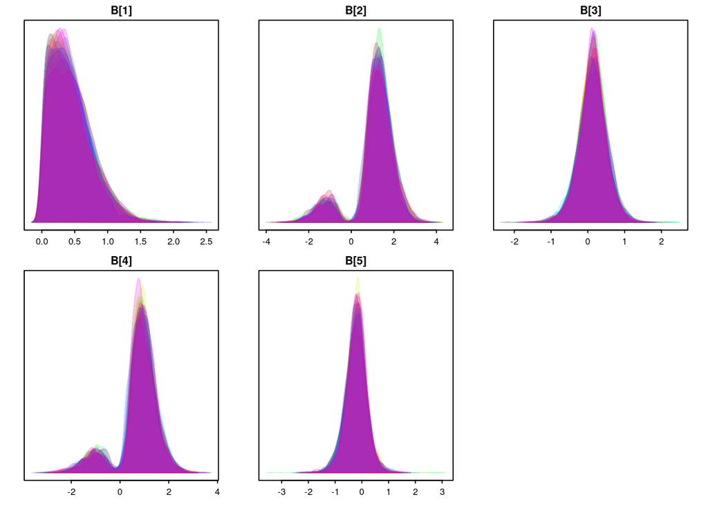

```r
# load("samples.RData") # list of length chains

#function for mode
getmode <- function(v) {
   uniqv <- unique(v)
   uniqv[which.max(tabulate(match(v, uniqv)))]
}

# Function to summarize the MCMC chains
CalcSummary <- function(mat) {
  Summs <- function(x) c(mean(x), median(x), getmode(x), quantile(x, probs = c(0.5, 0.025, 0.975)))
  summary = t(apply(mat, 2, Summs))
  colnames(summary) <- c("Mean", "Median", "Mode","St.Dev.",
                         "95%CI_low", "95%CI_upp")
  summary
}
postProcess <- function(chains,consts){
  # chains should be a list of length nchains
  total <- length(chains)
  pb <- txtProgressBar(min = 0, max = total, style = 3)
  i = 0
  lapply(chains, function(x,consts){
  res <- t(apply(x,1,function(iter, consts){
    # iter is one iteration of chain x that we need to correct for sign
    # we start by separating into the different components, B,  O, epsilon, varepsilon
    bs <- iter[grep("B",gsub(".*?(\\b[A-Za-z0-9 ]+\\b).*","\\1", names(iter)))]
    os <- iter[grep("O",gsub(".*?(\\b[A-Za-z0-9 ]+\\b).*","\\1", names(iter)))]
    varepsilon <- matrix(iter[grep("varepsilon",gsub(".*?(\\b[A-Za-z0-9 ]+\\b).*","\\1", names(iter)))],ncol=consts$d, nrow=consts$m)
        # epsilons, not to confuse with the varepsilons
    epsilon <- matrix(iter[-grep("varepsilon",gsub(".*?(\\b[A-Za-z0-9 ]+\\b).*","\\1", names(iter)))][grep("epsilon",gsub(".*?(\\b[A-Za-z0-9 ]+\\b).*","\\1", names(iter[-grep("varepsilon",gsub(".*?(\\b[A-Za-z0-9 ]+\\b).*","\\1", names(iter)))])))],ncol=consts$d, nrow = consts$n)

    # to matrix
    B <- matrix(bs,ncol=consts$d,nrow=consts$p)
    O <- matrix(os,ncol=consts$d,nrow=consts$t)

    # get sign of main diagonalentries for B
    signs <- sign(diag(B))
    if(all(signs>0)){ #if these are all positive, no sign swapping is needed, so  we're done
      return(iter)
    }else{
      sign.mat = diag(signs, ncol= consts$d,nrow=consts$d)
      # otherwise, we need to swap!
      B = B%*%sign.mat
      O = O %*% sign.mat
      epsilon = epsilon %*% sign.mat
      varepsilon = varepsilon %*% sign.mat
      # now put the sign-swapped coefs back
       iter[grep("B",gsub(".*?(\\b[A-Za-z0-9 ]+\\b).*","\\1", names(iter)))] <- c(B)
       iter[grep("O",gsub(".*?(\\b[A-Za-z0-9 ]+\\b).*","\\1", names(iter)))] <- c(O)
       iter[-grep("varepsilon",gsub(".*?(\\b[A-Za-z0-9 ]+\\b).*","\\1", names(iter)))][grep("epsilon",gsub(".*?(\\b[A-Za-z0-9 ]+\\b).*","\\1", names(iter[-grep("varepsilon",gsub(".*?(\\b[A-Za-z0-9 ]+\\b).*","\\1", names(iter)))])))] <- c(epsilon)
       iter[grep("varepsilon",gsub(".*?(\\b[A-Za-z0-9 ]+\\b).*","\\1", names(iter)))] <- c(varepsilon)
       #aaand to the next iteration
       return(iter)
    }
  }, consts = consts))
  i <<- i+1
  # update progressbar
  setTxtProgressBar(pb, i)
  # restore parameter names
  colnames(res) <- colnames(x)
  return(res)
  }, consts = consts)
}

# Name the chains in the list
# chains <- setNames(samples,paste0("chain", 1:length(samples)))

# post-process chains for sign-swapping
# chains <- postProcess(chains, consts = consts)
# I have already done that so loading it here
load(file="chains_post.RData")
# also create a matrix to get summary stats
chains.mat <- do.call(rbind,chains)
colnames(chains.mat) <- colnames(chains[[1]])
summary = CalcSummary(chains.mat)

# Put together in a list
out <- list(samples = chains, summary = summary)

library(basicMCMCplots)
par(mfrow=c(1,1))
# chainsPlot(out$samples, var = c("epsilon"), legend = F, densityplot = F)
chainsPlot(out$samples, var = c("B"), legend = F,traceplot=F)
```

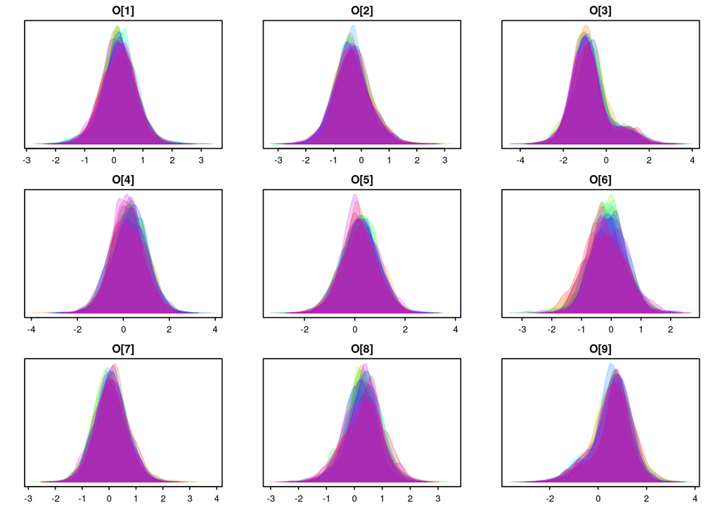

```r
chainsPlot(out$samples, var = c("O"), legend = F,traceplot=F)
```

```r
# chainsPlot(out$samples, var = c("Speciesd"), legend = F)
# chainsPlot(out$samples, var = c("Sitesd"), legend = F)
# chainsPlot(out$samples, var = c("LVsd"), legend = F)

# dev <- lapply(chains,function(x)x[,grep("deviance",colnames(x))])
# dev.rows<-lapply(dev,function(x)rowSums(x))
# unlist(lapply(dev.rows,which.max))#?
```

These look quite OK (after post-processing). Now we can create a plot of the LV-scores against their indices to inspect the results:

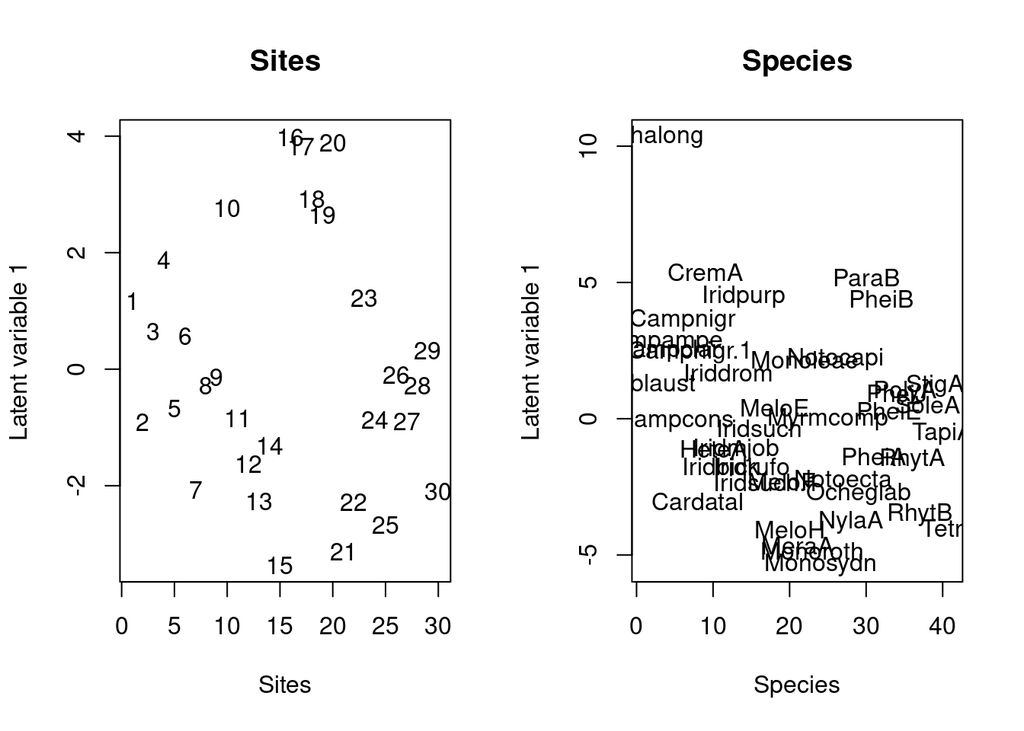

```r
par(mfrow=c(1,2))

# First a plot of the site scores
epsilon <- data.frame(out$summary[-grep("varepsilon",gsub(".*?(\\b[A-Za-z0-9 ]+\\b).*","\\1", row.names(out$summary))),][grep("epsilon",gsub(".*?(\\b[A-Za-z0-9 ]+\\b).*","\\1", row.names(out$summary[-grep("varepsilon",gsub(".*?(\\b[A-Za-z0-9 ]+\\b).*","\\1", row.names(out$summary))),]))),])
epsilon <- matrix(epsilon$Mean,ncol=consts$d)

B <- data.frame(out$summary[grep("B",gsub(".*?(\\b[A-Za-z0-9 ]+\\b).*","\\1", row.names(out$summary))),])
B <- matrix(B$Mean,ncol=consts$d)

LVs <- X%*%B+epsilon
#LVs
plot(LVs,type="n", xlab="Sites", ylab="Latent variable 1", main = "Sites")
text(LVs,labels=1:consts$n)

# Now the species loadings
varepsilon <- data.frame(out$summary[grep("varepsilon",gsub(".*?(\\b[A-Za-z0-9 ]+\\b).*","\\1", row.names(out$summary))),])
varepsilon <- matrix(varepsilon$Mean,ncol=consts$d)

O <- data.frame(out$summary[grep("O",gsub(".*?(\\b[A-Za-z0-9 ]+\\b).*","\\1", row.names(out$summary))),])
O <- matrix(O$Mean,ncol=consts$d)

gamma <- TR%*%O+varepsilon
#LVs
plot(gamma,type="n", xlab="Species", ylab="Latent variable 1", main = "Species")
text(gamma,labels=vegan::make.cepnames(colnames(Y)))
```

## More dimensions

More than one dimension requires adding extra identifiability constraints.

There are various ways to place the constraints, some more numerically stable than others. Generally, we note that the model on the link scale is similar to existing matrix decompositions, so that much on the required constraints can be learned from those.

Consequently, the model code here is:

```r
# Update our constants from before with the new number of LVs, rest remains the same
consts$d <- nLVs <- 2
# Model code
HO <- nimbleCode({
  for (i in 1:n) {
    for (j in 1:m) {
      eta[i,j] <- beta0[j] + sum(gammas[j,1:d]*LVsd[1:d]*zs[i,1:d])
      log(lambda[i, j]) <- eta[i, j]
      Y[i, j] ~ dpois(lambda[i, j])
    }
    for (q in 1:d) {
      XB[i, q] <- sum(X[i, 1:p]*B[1:p, q])
      epsilon[i,q] ~ dnorm(0,Sitesd[q])#Residual
      z[i,q] <- XB[i,q] + epsilon[i,q]
    }
  }

  for(j in 1:m) {
    for (q in 1:d) {
      omegaTR[j, q] <- sum(TR[j, 1:t]*O[1:t, q])
      varepsilon[j,q] ~ dnorm(0,Speciesd[q]) # Residual
      gamma[j,q] <- omegaTR[j,q] + varepsilon[j,q]
    }

    beta0[j] ~ dnorm(0, sd=1)
  }
  # Constraints to 0 on upper diagonal
  # stole some code from Boral for this - thanks Francis
  for(i in 1:(d-1)) {
    for(j in (i+1):(d)) {
      B[i,j] <- 0
      #O[i,j] <- 0
    }
  }

  for(i in 1:d) {
    # diagonal elements
    B[i,i] ~ dnorm(0,1)
    #O[i,i] ~ dnorm(0,1)#T(dnorm(0,1),0,Inf)
    ## standardizing z and gamma
    zmu[i] <- mean(z[1:n,i])
    zs[1:n,i] <- (z[1:n,i]-zmu[i])/sqrt(mean((z[1:n,i] - zmu[i])^2)) #scale z to unit sd and center
    gammamu[i] <- mean(gamma[1:m,i])
    gammas[1:m,i] <- (gamma[1:m,i]-gammamu[i])/sqrt(mean((gamma[1:m,i] - gammamu[i])^2)) #scale gamma to unit sd and center
    # priors for scales
    Sitesd[i] ~ dexp(1)
    Speciesd[i] ~ dexp(1)
    LVsd[i] ~ dexp(1)
    }

  ## Free lower diagonals
  for(i in 2:d) {
    for(j in 1:(i-1)) {
      B[i,j] ~ dnorm(0,1)
      #O[i,j] ~ dnorm(0,1)
      }
    }
  for(i in (d+1):p) { for(j in 1:(d)) { B[i,j] ~dnorm(0,1) } } ## All other elements
  #for(i in (d+1):t) { for(j in 1:(d)) { O[i,j] ~dnorm(0,1) } } ## All other elements

  for(tr in 1:t){
    for(q in 1:d){
      O[tr,q] ~dnorm(0,1)
    }
  }
})
```

We create a new function to simulate starting values from the prior distributions:

```r
inits<-function(consts){
  B = matrix(rnorm(consts$d*consts$p),ncol=consts$d)
  B[upper.tri(B)] = 0
  O = matrix(rnorm(consts$d*consts$t),nrow=consts$t)
  varepsilon = mvtnorm::rmvnorm(consts$m,rep(0,consts$d),diag(consts$d))
  epsilon = mvtnorm::rmvnorm(consts$n,rep(0,consts$d),diag(consts$d))
  list(
    B = B,
    O = O,
    epsilon = epsilon,
    varepsilon = varepsilon,
    Sitesd = rexp(consts$d),
    Speciesd = rexp(consts$d),
    beta0 = rnorm(consts$m),
    LVsd = rexp(consts$d)
  )
}
```

put it all together, and run it for a bit longer time than before:

```r
library(parallel)
nimble_cluster <- makeCluster(40)

modit <- function(seed,dat,code,inits,consts){
  library(nimble)
  mod <- nimbleModel(code = code, name = "HO", constants = consts, inits = inits(consts),
                    data = dat)
model <- compileNimble(mod)
  conf <- configureMCMC(model, monitors = c("beta0","Speciesd","Sitesd","LVsd","B","O","epsilon","varepsilon","beta0"), print = TRUE)
conf$removeSamplers(c('epsilon', 'varepsilon'))
conf$addSampler(target = 'epsilon',
                      type = "RW_block", control = list(tries = 10))
conf$addSampler(target = 'varepsilon',
                      type = "RW_block", control = list(tries = 10))
mcmc <- buildMCMC(conf)
cmcmc <- compileNimble(mcmc, project = model)

 return(runMCMC(cmcmc,  niter=1000000, nburnin = 50000, thin=100,nchains = 1, samplesAsCodaMCMC = T))
}

samples <- parLapply(cl = nimble_cluster, fun = modit,
                              dat = dat,
                              code = HO,
                              inits = inits,
                              consts = consts, X = 1:20)
stopCluster(nimble_cluster)
save(samples,file="samples2.RData")
#new run changes niter to 1mil, nburn 50k, thin 100
```

## Results

I have saved the results after running the model with 20 chains on a server at NTNU, so I load those here.

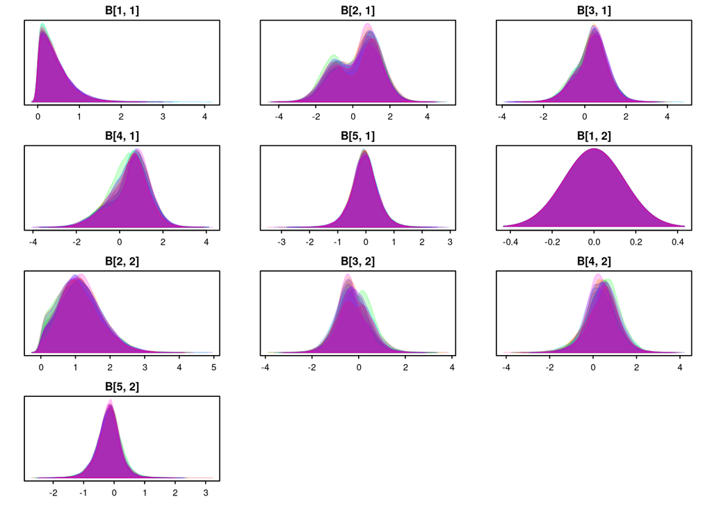

```r
# load("samples2.RData") # list of length chains
par(mfrow=c(1,1))
# Name the chains in the list
# chains <- setNames(samples,paste0("chain", 1:length(samples)))

# post-process chains for sign-swapping
# chains <- postProcess(chains, consts = consts)
# I have already done that so loading it here
# save(chains,file="chains_post2.RData")
load("chains_post2.RData")
# also create a matrix to get summary stats
chains.mat <- do.call(rbind,chains)
colnames(chains.mat) <- colnames(chains[[1]])
summary = CalcSummary(chains.mat)

# Put together in a list
out <- list(samples = chains, summary = summary)

library(basicMCMCplots)
# chainsPlot(out$samples, var = c("epsilon[10, 2]"), legend = F, densityplot = F)
# chainsPlot(out$samples, var = c("beta0"), legend = F,densityplot = F)
chainsPlot(out$samples, var = c("B"), legend = F, traceplot=F)
```

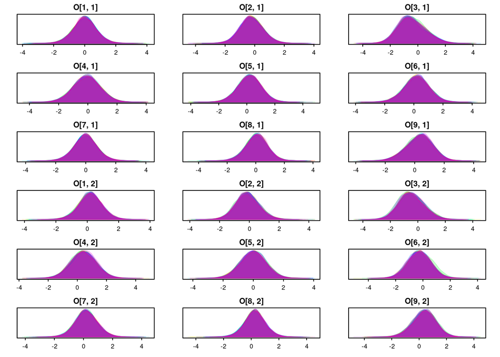

```r
chainsPlot(out$samples, var = c("O"), legend = F,traceplot=F)
```

```r
# chainsPlot(out$samples, var = c("Speciesd"), legend = F)
# chainsPlot(out$samples, var = c("Sitesd"), legend = F)
# chainsPlot(out$samples, var = c("LVsd"), legend = F)
```

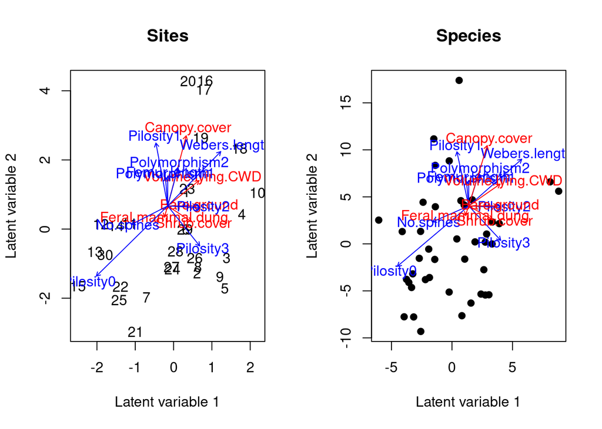

```r
par(mfrow=c(1,2))

# create the site scores
epsilon <- data.frame(out$summary[-grep("varepsilon",gsub(".*?(\\b[A-Za-z0-9 ]+\\b).*","\\1", row.names(out$summary))),][grep("epsilon",gsub(".*?(\\b[A-Za-z0-9 ]+\\b).*","\\1", row.names(out$summary[-grep("varepsilon",gsub(".*?(\\b[A-Za-z0-9 ]+\\b).*","\\1", row.names(out$summary))),]))),])
epsilon <- matrix(epsilon$Mean,ncol=consts$d)

B <- data.frame(out$summary[grep("B",gsub(".*?(\\b[A-Za-z0-9 ]+\\b).*","\\1", row.names(out$summary))),])
B <- matrix(B$Mean,ncol=consts$d)

LVs <- X%*%B+epsilon

# Now the species loadings
varepsilon <- data.frame(out$summary[grep("varepsilon",gsub(".*?(\\b[A-Za-z0-9 ]+\\b).*","\\1", row.names(out$summary))),])
varepsilon <- matrix(varepsilon$Mean,ncol=consts$d)

O <- data.frame(out$summary[grep("O",gsub(".*?(\\b[A-Za-z0-9 ]+\\b).*","\\1", row.names(out$summary))),])
O <- matrix(O$Mean,ncol=consts$d)

gamma <- TR%*%O+varepsilon


#plot LVs
plot(LVs,type="n", xlab="Latent variable 1", ylab="Latent variable 2", main = "Sites")
text(LVs,labels=1:consts$n)

# plot arrows
marg <- par("usr")
origin <- c(mean(marg[1:2]), mean(marg[3:4]))
Xlength <- sum(abs(marg[1:2]))/2
Ylength <- sum(abs(marg[3:4]))/2
ends <- B / max(abs(B)) * min(Xlength, Ylength) * .8
arrows(
  x0 = origin[1],
  y0 = origin[2],
  x1 = ends[,
            1] + origin[1],
  y1 = ends[, 2] + origin[2],
  col = "red",
  length = 0.05)
text(
  x = origin[1] + ends[, 1] * 1.1,
  y = origin[2] + ends[, 2] * 1.1,
  labels = colnames(X),
  col = "red")

# plot arrows
marg <- par("usr")
origin <- c(mean(marg[1:2]), mean(marg[3:4]))
Xlength <- sum(abs(marg[1:2]))/2
Ylength <- sum(abs(marg[3:4]))/2
ends <- O / max(abs(O)) * min(Xlength, Ylength) * .8
arrows(
  x0 = origin[1],
  y0 = origin[2],
  x1 = ends[,
            1] + origin[1],
  y1 = ends[, 2] + origin[2],
  col = "blue",
  length = 0.05)
text(
  x = origin[1] + ends[, 1] * 1.1,
  y = origin[2] + ends[, 2] * 1.1,
  labels = colnames(TR),
  col = "blue")

#plot gammas
plot(gamma,type="n", xlab="Latent variable 1", ylab="Latent variable 2", main = "Species")
points(gamma, pch=19)#,labels=vegan::make.cepnames(colnames(Y)))

# plot arrows
marg <- par("usr")
origin <- c(mean(marg[1:2]), mean(marg[3:4]))
Xlength <- sum(abs(marg[1:2]))/2
Ylength <- sum(abs(marg[3:4]))/2
ends <- O / max(abs(O)) * min(Xlength, Ylength) * .8
arrows(
  x0 = origin[1],
  y0 = origin[2],
  x1 = ends[,
            1] + origin[1],
  y1 = ends[, 2] + origin[2],
  col = "blue",
  length = 0.05)
text(
  x = origin[1] + ends[, 1] * 1.1,
  y = origin[2] + ends[, 2] * 1.1,
  labels = colnames(TR),
  col = "blue")

# plot arrows
marg <- par("usr")
origin <- c(mean(marg[1:2]), mean(marg[3:4]))
Xlength <- sum(abs(marg[1:2]))/2
Ylength <- sum(abs(marg[3:4]))/2
ends <- B / max(abs(B)) * min(Xlength, Ylength) * .8
arrows(
  x0 = origin[1],
  y0 = origin[2],
  x1 = ends[,
            1] + origin[1],
  y1 = ends[, 2] + origin[2],
  col = "red",
  length = 0.05)
text(
  x = origin[1] + ends[, 1] * 1.1,
  y = origin[2] + ends[, 2] * 1.1,
  labels = colnames(X),
  col = "red")
```

We can also look at some summary statistics for the scale parameters of the latent variables, species-specific residuals and site-specific residuals, respectively:

```r
out$summary[grep("LVsd",gsub(".*?(\\b[A-Za-z0-9 ]+\\b).*","\\1", row.names(out$summary))),]
```

```
##              Mean    Median      Mode   St.Dev. 95%CI_low 95%CI_upp
## LVsd[1] 0.7311208 0.7356148 0.8506377 0.7356148 0.5202055 0.9397600
## LVsd[2] 0.7263196 0.7225228 0.6531660 0.7225228 0.5208351 0.9383404
```

```r
LVsd <- out$summary[grep("LVsd",gsub(".*?(\\b[A-Za-z0-9 ]+\\b).*","\\1", row.names(out$summary))),"Mean"]
out$summary[grep("Speciesd",gsub(".*?(\\b[A-Za-z0-9 ]+\\b).*","\\1", row.names(out$summary))),]
```

```
##                   Mean     Median         Mode    St.Dev.   95%CI_low 95%CI_upp
## Speciesd[1] 0.04238084 0.02761545 0.0004069643 0.02761545 0.002279903 0.1736834
## Speciesd[2] 0.03797254 0.02362039 0.0002400888 0.02362039 0.001870337 0.1608619
```

```r
Speciesd <- out$summary[grep("Speciesd",gsub(".*?(\\b[A-Za-z0-9 ]+\\b).*","\\1", row.names(out$summary))),"Mean"]
out$summary[grep("Sitesd",gsub(".*?(\\b[A-Za-z0-9 ]+\\b).*","\\1", row.names(out$summary))),]
```

```
##                Mean    Median       Mode   St.Dev.  95%CI_low 95%CI_upp
## Sitesd[1] 0.3815539 0.2686116 0.01183191 0.2686116 0.03946132  1.401245
## Sitesd[2] 0.5425310 0.3982201 0.00861841 0.3982201 0.05989718  1.875297
```

```r
Sitesd <- out$summary[grep("Sitesd",gsub(".*?(\\b[A-Za-z0-9 ]+\\b).*","\\1", row.names(out$summary))),"Mean"]
```

these tell us how well the predictors explain the ordination; the species- and site-specific scale parameters would be zero if the predictors fully explained the ordination. The scale parameters for the latent variables are similar to singular values (the square root of eigenvalues) in a classical ordination; they reflect a dimension its importance to the response.

## Residual covariance matrix

The residual covariance matrix of the model (where you calculate species associations from) is determined by three terms:

1. $\boldsymbol{X}\boldsymbol{B}\boldsymbol{\Sigma}\boldsymbol{\varepsilon}_j \sim \mathcal{N}(0,\boldsymbol{X}\boldsymbol{B}\boldsymbol{\Sigma}\text{diag}(\boldsymbol{\delta}^2)\boldsymbol{\Sigma}\boldsymbol{B}^\top\boldsymbol{X}^\top)$
2. $\boldsymbol{TR}\boldsymbol{\omega}\boldsymbol{\Sigma}\boldsymbol{\epsilon}_i\sim \mathcal{N}(0,\boldsymbol{T}\boldsymbol{\omega}\boldsymbol{\Sigma}\text{diag}(\boldsymbol{\sigma}^2)\boldsymbol{\Sigma}\boldsymbol{\omega}^\top\boldsymbol{T}^\top)$
3. $\boldsymbol{\epsilon}_i^\top\boldsymbol{\varepsilon}_j \sum \limits^{d}_{q=1}\Sigma_{q,q}\sigma_q\delta_q\sim \mathcal{K}_0(\sigma^{-1}_q\delta^{-1}_q\vert\epsilon_{iq}\varepsilon_{iq}\vert)$,

Consequently, for a species association matrix where we consider the block of the covariance matrix where $i = i2$, or for the site-to-site matrix where we consider the block $j = j2$, we have:

$$\begin{split}
\Sigma_{j,j2} &=
\boldsymbol{x}_i^\top\boldsymbol{B}\boldsymbol{\Sigma}\text{cov}(\boldsymbol{\varepsilon}_j,\boldsymbol{\varepsilon}_{j2})
\boldsymbol{\Sigma}\boldsymbol{B}^\top\boldsymbol{x}_{i} +
\text{cov}(\boldsymbol{\epsilon}_i^\top
\boldsymbol{\Sigma}\boldsymbol{\varepsilon}_j,\boldsymbol{\epsilon}_{i}^\top
\boldsymbol{\Sigma} \boldsymbol{\varepsilon}_{j2}) +
\boldsymbol{tr}_{j}^\top\boldsymbol{\omega}\boldsymbol{\Sigma}\text{var}(\boldsymbol{\epsilon}_{i},\boldsymbol{\epsilon}_{i})\boldsymbol{\Sigma}\boldsymbol{\omega}^\top\boldsymbol{tr}_{j2}
\\
&=
\boldsymbol{x}_i^\top\boldsymbol{B}\boldsymbol{\Sigma}\text{cov}(\boldsymbol{\varepsilon}_j,\boldsymbol{\varepsilon}_{j2})
\boldsymbol{\Sigma}\boldsymbol{B}^\top\boldsymbol{x}_{i} +
\boldsymbol{tr}_{j}^\top\boldsymbol{\omega}\boldsymbol{\Sigma}\text{diag}(\boldsymbol{\sigma}^2)\boldsymbol{\Sigma}\boldsymbol{\omega}^\top\boldsymbol{tr}_{j2}+
2\text{tr}\{\text{diag}(\boldsymbol{\delta}^2)\boldsymbol{\Sigma}\text{diag}(\boldsymbol{\sigma}^2)\boldsymbol{\Sigma}\},
\end{split}$$

and

$$\begin{equation}
\Sigma_{i,i2} =
\boldsymbol{tr}_{j}^\top\boldsymbol{\omega}\boldsymbol{\Sigma}\text{cov}(\boldsymbol{\epsilon}_{i},\boldsymbol{\epsilon}_{i2})\boldsymbol{\Sigma}\boldsymbol{\omega}^\top\boldsymbol{tr}_{j}
+
\boldsymbol{x}_i^\top\boldsymbol{B}\boldsymbol{\Sigma}\text{diag}(\boldsymbol{\delta}^2)\boldsymbol{\Sigma}\boldsymbol{B}^\top\boldsymbol{x}_{i2}
+
2\text{tr}\{\text{diag}(\boldsymbol{\delta}^2)\boldsymbol{\Sigma}\text{diag}(\boldsymbol{\sigma}^2)\boldsymbol{\Sigma}\}.
\end{equation}$$

This shows that the covariance of species is determined by traits, LV-specific variation and sites’ residual variation, and the covariance between sites is determined by the environment, LV-specific variation and species’ residual variation. We can visualize those matrices here for (e.g.,) the first site and first species, respectively.

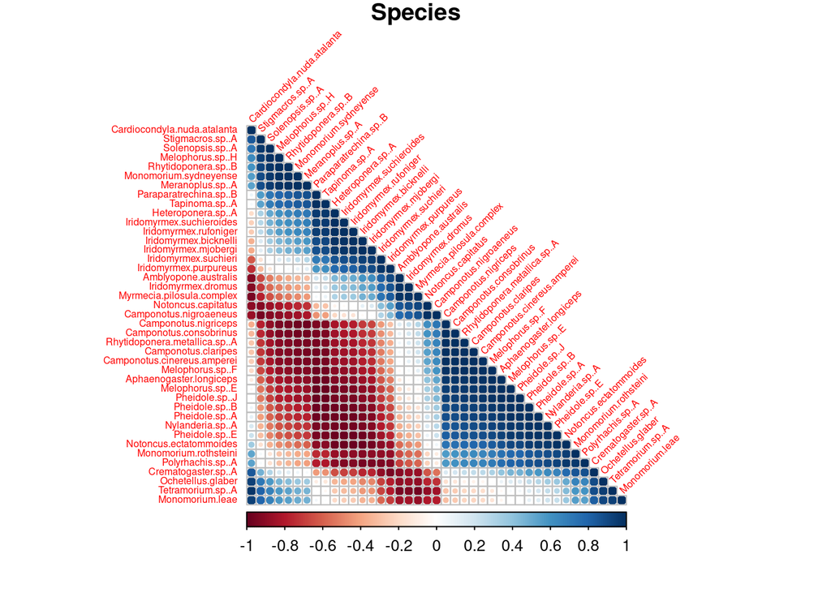

```r
#species
spec.mat <- matrix(0,nrow=m,ncol=m)
Sigma <- diag(LVsd^2)
Sigma.sp <- diag(Speciesd^2)
Sigma.si <- diag(Sitesd^2)

for(j in 1:m){
  for(j2 in 1:m){
    if(j==j2){
      spec.mat[j,j2] = X[1,,drop=F]%*%B%*%Sigma%*%Sigma.sp%*%t(B)%*%t(X[1,,drop=F])
    }
    spec.mat[j,j2] = spec.mat[j,j2] + TR[j,,drop=F]%*%O%*%Sigma%*%Sigma.si%*%Sigma%*%t(O)%*%t(TR[j2,,drop=F]) + 2*sum(diag((Sigma.sp%*%Sigma%*%Sigma.si%*%Sigma)))
  }
}

spec.cor.mat <- cov2cor(spec.mat)
colnames(spec.cor.mat) <- row.names(spec.cor.mat) <- colnames(Y)
corrplot::corrplot(spec.cor.mat,type = "lower",order = "AOE", main = "Species", mar = c(1,1,1,1),tl.srt=45,tl.cex = .5)
```

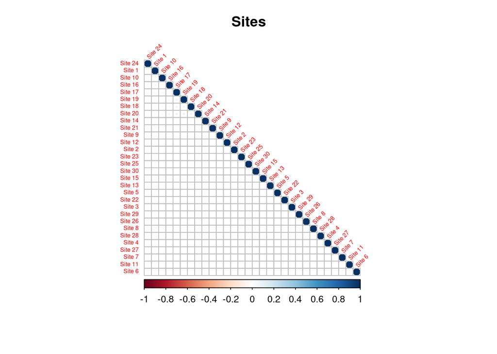

```r
#sites
site.mat <- matrix(0,nrow=n,ncol=n)

for(i in 1:n){
  for(i2 in 1:n){
    if(i==i2){
      site.mat[i,i2] = TR[1,,drop=F]%*%O%*%Sigma%*%Sigma.si%*%t(O)%*%t(TR[1,,drop=F])
    }
    site.mat[i,i2] = site.mat[i,i2] + X[i,,drop=F]%*%B%*%Sigma%*%Sigma.sp%*%Sigma%*%t(B)%*%t(X[i2,,drop=F]) + 2*sum(diag((Sigma.sp%*%Sigma%*%Sigma.si%*%Sigma)))
  }
}

site.cor.mat <- cov2cor(site.mat)
colnames(site.cor.mat) <- row.names(site.cor.mat) <- paste("Site", 1:n)
corrplot::corrplot(site.cor.mat,type = "lower",order = "AOE", main = "Sites", mar = c(3,3,3,3),tl.srt=45,tl.cex = .5)
```